# Exercise 7

Hubert Rehrauer

30 10 2017

## Comparison of Expression Estimates

The data set consists for 3 Normal samples and 3 Treated samples with 2.5 Mio reads each. The reads are simulated to come from genes on the human chromosome 1.

The expression values from featureCounts were created with: We use the library subread to generate the counts

```r
library(Rsubread)
countResult1 = featureCounts(..., strandSpecific=0,
                                 GTF.featureType="exon", GTF.attrType="gene_id", useMetaFeatures=TRUE,
                                 allowMultiOverlap=TRUE, countMultiMappingReads=TRUE)
save(countResult1, file="countResult1.RData")
countResult2 = featureCounts(..., strandSpecific=0,
                                 GTF.featureType="exon", GTF.attrType="gene_id", useMetaFeatures=TRUE,
                                 allowMultiOverlap=TRUE, countMultiMappingReads=TRUE, fraction=TRUE)
save(countResult2, file="countResult2.RData")
```

The RSEM data were generated with

```bash
rsem-calculate-expression .... --calc-pme --calc-ci --strandedness none ...
```

For documentation see: http://deweylab.github.io/RSEM/rsem-calculate-expression.html

–calc-pme … Run RSEM’s collapsed Gibbs sampler to calculate posterior mean estimates –calc-ci … Calculate 95% credibility intervals and posterior mean estimate ?? –strand-specific … The RNA-Seq protocol used to generate the reads is strand specific, i.e., all (upstream) reads are derived from the forward strand. The ‘–norc’ Bowtie/Bowtie 2 option will be used, which disables alignment to the reverse strand of transcripts

## Exercises

### 1. Depending on the featureCount mode, how many alignments are ignored during counting?

**See numeric ratios included with answer to Q2.**

##### countMultiMappingReads

- logical indicating if multi-mapping reads/fragments should be counted. If TRUE, a multi-mapping read will be counted up to N times if it has N reported mapping locations. This function uses the ???NH??? tag to find multi-mapping reads.

##### allowMultiOverlap

- logical indicating if a read is allowed to be assigned to more than one feature (or meta-feature) if it is found to overlap with more than one feature (or meta-feature = gene, as in this case).

##### strandSpecific

- integer indicating if strand-specific read counting should be performed. It has three possible values: 0 (unstranded), 1 (stranded) and 2 (reversely stranded)

##### fraction

- logical indicating if fractional counts will be produced for multi-mapping reads. If TRUE, a fractional count, 1/n, will be generated for each reported alignment of a multi-mapping read, where n is the total number of alignments reported for that read. countMultiMappingReads must be set to TRUE when fraction is TRUE

### 2. Compare the counts from featureCounts with the genelevel counts from RSEM. Which genes have different values?

```r
loadRData <- function(fileName){
#loads an RData file, and returns it
    load(fileName)
    get(ls()[ls() != "fileName"])
}
```

**STAR was used for alignement**

```r
feature_counts <- loadRData("countResult1.RData")
# strandSpecific=0, GTF.featureType="exon", GTF.attrType="gene_id", useMetaFeatures=TRUE, allowMultiOverlap=TRUE, countMultiMappingReads=TRUE
indexing <- factor(feature_counts$annotation$GeneID)
colnames(feature_counts$counts) <- gsub(".*\\.([NT][0-9])\\..*","\\1", colnames(feature_counts$counts))

feature_counts_frac <- loadRData("countResult2.RData")
# strandSpecific=0, GTF.featureType="exon", GTF.attrType="gene_id", useMetaFeatures=TRUE, allowMultiOverlap=TRUE, countMultiMappingReads=TRUE, fraction=TRUE
# check ordering
colnames(feature_counts_frac$counts) <- gsub(".*\\.([NT][0-9])\\..*","\\1", colnames(feature_counts_frac$counts))

sum(indexing == factor(feature_counts_frac$annotation$GeneID)) == dim(feature_counts$counts)[1]
```

```
## [1] TRUE
```

```r
unassigned_frac <- (feature_counts_frac$stat[startsWith(feature_counts_frac$stat$Status, "Unassigned"), 2: ncol(feature_counts_frac$stat)])
assigned_frac <- (feature_counts_frac$stat[startsWith(feature_counts_frac$stat$Status, "Assigned"), 2: ncol(feature_counts_frac$stat)])
sum(unassigned_frac) / sum(assigned_frac)
```

```
## [1] 0.002337687
```

```r
unassigned <- (feature_counts$stat[startsWith(feature_counts$stat$Status, "Unassigned"), 2: ncol(feature_counts$stat)])
assigned <- (feature_counts$stat[startsWith(feature_counts$stat$Status, "Assigned"), 2: ncol(feature_counts$stat)])
sum(unassigned) / sum(assigned)
```

```
## [1] 0.02834818
```

**Bowtie was used for alignement**

```r
rsem.files <- list.files(path = "RSEM_counts/", pattern = ".genes.results$", full.names = TRUE)
ncols <- length(rsem.files)
nrows <- length(indexing)
rsem_gene_counts <- matrix(NA, nrows, ncols, dimnames = list(indexing, 1:ncols))

for (i in 1:length(rsem.files)){
  rsem <- read.table(rsem.files[i], sep="\t", header=TRUE)

  names <- rsem$gene_id
  counts <- rsem$expected_count #rsem[, c("gene_id", "expected_count")]
  ordering <- match(indexing, names)
  counts <- counts[ordering]

  col_name <- gsub(".*/([NT][0-9])\\..*","\\1", rsem.files[i])
  colnames(rsem_gene_counts)[i] <- col_name

  rsem_gene_counts[ ,i] <- counts
}
```

```r
twosided_tf <- rep(FALSE, nrow(rsem_gene_counts))
p_vals <- vector(mode = "numeric", length =  nrow(rsem_gene_counts))

for (row in 1: nrow(rsem_gene_counts)){
  x0 <- rsem_gene_counts[row, ]
  x1 <- feature_counts$counts[row, ]
  res_twosided <- t.test(x0, x1, alternative = "two.sided")$p.value

  if (is.nan(res_twosided)){
    res_twosided <- 1 # rows are identical
  }
  if (res_twosided < .05){
    twosided_tf[row] <- TRUE
  }
  p_vals[row] <- res_twosided
}

# t.res <- apply(cbind(rsem_gene_counts, feature_counts$counts), 1, function(x) t.test(x[1:6], x[7:12], alternative = "two.sided"))
# p_vals <- unlist(lapply(t.res, function(x) x$p.value))
# p_vals[is.nan(p_vals)] <- 1 # identical entries
# sum((p_vals < 0.05) == twosided_tf) == nrow(rsem_gene_counts) # check that approaches equivalent
```

```r
different_genes <- row.names(rsem_gene_counts)[p_vals < .01]
#different_genes
length(different_genes)
```

```
## [1] 271
```

### 3. How does the sum of the counts in RSEM compare to the number of the aligned reads?

‘expected_count’ is the sum of the posterior probability of each read comes from this transcript over all reads. Because 1) each read aligning to this transcript has a probability of being generated from background noise; 2) RSEM may filter some alignable low quality reads, the sum of expected counts for all transcript are generally less than the total number of reads aligned.

```r
# see https://github.com/deweylab/RSEM/blob/master/cnt_file_description.txt

rsem.files <- list.files(path = "RSEM_counts/", pattern = ".cnt$", full.names = TRUE, recursive = TRUE)

num_total <- vector(mode = "numeric", length = length(rsem.files))
num_aligned <- vector(mode = "numeric", length = length(rsem.files))
num_unaligned <- vector(mode = "numeric", length = length(rsem.files))

for (i in 1:length(rsem.files)){
  rsem.cnts <- read.table(rsem.files[i], sep="", header=FALSE, nrows = 1)
  num_total[i] <- rsem.cnts[ , 4]
  num_aligned[i] <- rsem.cnts[ , 2]
  num_unaligned[i] <- rsem.cnts[ , 1] + rsem.cnts[ , 3]
}
sum(num_unaligned) / sum(num_aligned)
```

```
## [1] 0.003493936
```

```r
#sum(num_unaligned) / sum(rsem_gene_counts)
```

### 4. Compute pair-wise correlation of the samples based on the isoform counts and gene level counts

```r
rsem.files <- list.files(path = "RSEM_counts/", pattern = ".isoforms.results$", full.names = TRUE)

for (i in 1:length(rsem.files)){
  rsem <- read.table(rsem.files[i], sep="\t", header=TRUE)

  names <- rsem$gene_id
  names_isof <- rsem$transcript_id
  counts <- rsem$expected_count

  #ordering <- match(indexing, names) # not needed now
  #counts <- counts[ordering]

  if (i == 1){
    rsem_isof_counts <- matrix(NA, length(names), ncols, dimnames = list(names_isof, 1:ncols))
  }

  col_name <- gsub(".*/([NT][0-9])\\..*","\\1", rsem.files[i])
  colnames(rsem_isof_counts)[i] <- col_name

  rsem_isof_counts[ ,i] <- counts
}
```

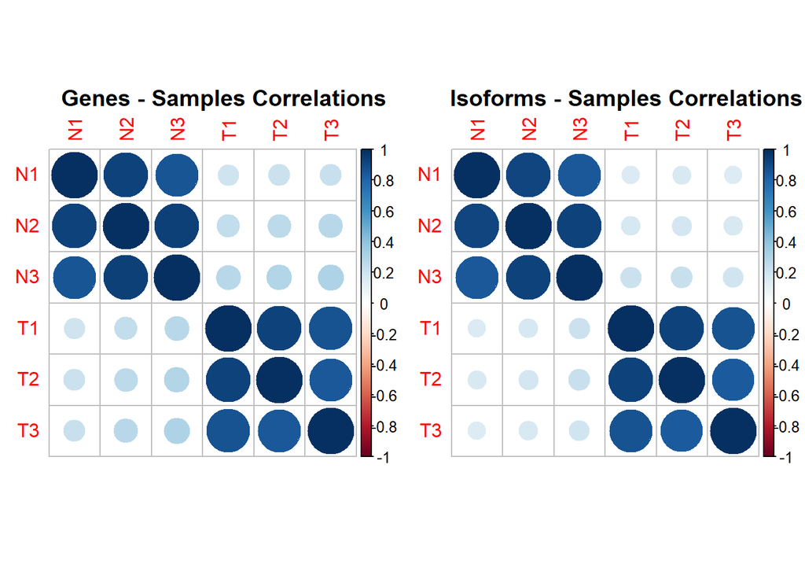

```r
cor_genes <- cor(rsem_gene_counts, use = "pairwise")
cor_isof <- cor(rsem_isof_counts, use = "pairwise")

par(mfrow=c(1,2))
corrplot::corrplot(cor_genes, method = "circle", cl.pos="r")
title("Genes - Samples Correlations", line = -0.5)

corrplot::corrplot(cor_isof, method = "circle", cl.pos="r")
title("Isoforms - Samples Correlations", line = -0.5)
```